# Assignment 2

Kai Xing

3/29/2022

# Suits - Introduction

### Overview

(From [Wikipedia](https://en.wikipedia.org/wiki/List_of_Suits_episodes)) Suits is an American television drama series created by *Aaron Korsh*, which premiered on June 23, 2011 on the USA Network. It revolves around *Mike Ross* (*Patrick J. Adams*), who begins working as a law associate for *Harvey Specter* (*Gabriel Macht*), despite never attending law school. The show focuses on *Harvey* and *Mike* managing to close cases, while maintaining *Mike*’s secret.

The series was renewed for an eighth season on January 30, 2018.[1] In January 2019, the series was renewed for a ninth and final season which premiered on July 17, 2019.[2] During the course of the series, 134 episodes of Suits aired over nine seasons, between June 23, 2011, and September 25, 2019.

### U.S. viewers per episode for all seasons (millions)

| Season |  | Episode number |  |  |  |  |  |  |  |  |  |  |  |  |  |  |  |
| --- | --- | --- | --- | --- | --- | --- | --- | --- | --- | --- | --- | --- | --- | --- | --- | --- | --- |
|  |  | 1 | 2 | 3 | 4 | 5 | 6 | 7 | 8 | 9 | 10 | 11 | 12 | 13 | 14 | 15 | 16 |
|  | 1 | 4.64 | 3.89 | 4.53 | 4.38 | 4.38 | 4.44 | 4.03 | 3.96 | 4.45 | 3.82 | 3.96 | 3.47 | N/A |  |  |  |
|  | 2 | 3.47 | 3.80 | 3.88 | 3.70 | 3.72 | 3.89 | 3.41 | 3.42 | 4.00 | 4.48 | 3.57 | 3.75 | 3.36 | 3.07 | 2.90 | 3.20 |
|  | 3 | 2.93 | 2.89 | 2.48 | 2.99 | 2.79 | 2.76 | 2.79 | 3.52 | 2.95 | 3.16 | 2.28 | 2.28 | 2.35 | 2.53 | 2.50 | 2.40 |
|  | 4 | 2.50 | 2.65 | 2.76 | 2.42 | 2.33 | 2.70 | 2.81 | 2.59 | 2.59 | 2.76 | 1.87 | 1.67 | 1.46 | 1.70 | 1.80 | 1.55 |
|  | 5 | 2.13 | 2.27 | 2.16 | 2.38 | 2.10 | 2.16 | 2.08 | 2.31 | 2.30 | 2.34 | 1.74 | 1.51 | 1.71 | 1.58 | 1.73 | 1.71 |
|  | 6 | 1.85 | 1.65 | 1.78 | 1.81 | 1.51 | 1.68 | 1.83 | 1.88 | 1.87 | 1.92 | 1.37 | 1.53 | 1.28 | 1.21 | 1.25 | 1.13 |
|  | 7 | 1.40 | 1.36 | 1.41 | 1.41 | 1.29 | 1.47 | 1.35 | 1.51 | 1.64 | 1.68 | 1.18 | 1.06 | 0.95 | 0.99 | 1.09 | 1.07 |
|  | 8 | 1.27 | 1.18 | 1.16 | 1.09 | 1.15 | 1.22 | 1.13 | 1.30 | 1.07 | 1.08 | 0.82 | 0.91 | 0.77 | 0.78 | 0.69 | 0.74 |
|  | 9 | 1.04 | 1.04 | 0.94 | 1.00 | 0.96 | 1.05 | 1.07 | 0.97 | 0.96 | 0.86 | N/A |  |  |  |  |  |

### Ratings for season 9

| No. | Title | Air date | Rating (18–49) | Viewers (millions) | DVR (18–49) | DVR viewers (millions) | Total (18–49) | Total viewers (millions) |
| --- | --- | --- | --- | --- | --- | --- | --- | --- |
| 1 | “Everything’s Changed” | July 17, 2019 | 0.2 | 1.04<sup>[4]</sup> | 0.3 | 1.24 | 0.5 | 2.28<sup>[17]</sup> |
| 2 | “Special Master” | July 24, 2019 | 0.2 | 1.04<sup>[5]</sup> | 0.3 | 1.08 | 0.5 | 2.12<sup>[18]</sup> |
| 3 | “Windmills” | July 31, 2019 | 0.2 | 0.94<sup>[6]</sup> | 0.3 | 1.17 | 0.5 | 2.11<sup>[19]</sup> |
| 4 | “Cairo” | August 7, 2019 | 0.2 | 1.00<sup>[7]</sup> | N/A | 1.06 | N/A | 2.06<sup>[20]</sup> |
| 5 | “If the Shoe Fits” | August 14, 2019 | 0.2 | 0.96<sup>[8]</sup> | 0.3 | 1.22 | 0.5 | 2.18<sup>[21]</sup> |
| 6 | “Whatever It Takes” | August 21, 2019 | 0.2 | 1.05<sup>[9]</sup> | 0.2 | 0.94 | 0.4 | 1.99<sup>[22]</sup><sup>[a]</sup> |
| 7 | “Scenic Route” | September 4, 2019 | 0.2 | 1.07<sup>[10]</sup> | 0.2 | 0.85 | 0.4 | 1.92<sup>[23]</sup><sup>[a]</sup> |
| 8 | “Prisoner’s Dilemma” | September 11, 2019 | 0.2 | 0.97<sup>[11]</sup> | 0.2 | 0.84 | 0.3 | 1.80<sup>[24]</sup><sup>[a]</sup> |
| 9 | “Thunder Away” | September 18, 2019 | 0.2 | 0.96<sup>[12]</sup> | 0.2 | 0.92 | 0.4 | 1.88<sup>[25]</sup><sup>[a]</sup> |
| 10 | “One Last Con” | September 25, 2019 | 0.2 | 0.86<sup>[13]</sup> | 0.2 | 0.93 | 0.4 | 1.79<sup>[26]</sup><sup>[a]</sup> |

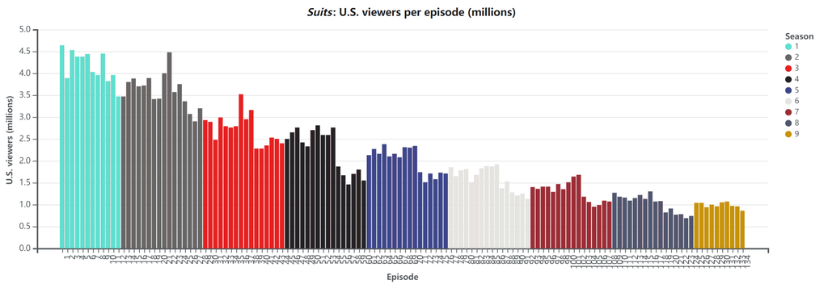

From the above graph, it is clear to see that U.S. viewers for Suits have been decreased season by season, but it was still a top-three ratings earner for USA Network, in both the demo and total audience size.